# C09 — Warsztat projektu: od scenariusza do dwóch małych analiz

Zarządzanie informacją — ćwiczenie i zadanie Z09 — 2026/27

2026/27

# Początek pracy na ćwiczeniu C09

Otwórz swój projekt kursu w Posit Cloud albo RStudio na własnym komputerze; pakiet kursu `badaniaZI` jest w nim zainstalowany. Dwa polecenia z następnego bloku wpisujesz w konsoli RStudio, czyli w dolnym panelu ze znakiem `>`; w miejsce `TWOJE_ID` wpisz swoje ID, a w miejsce `Imię Nazwisko` — swoje imię i nazwisko. Dokument PDF zawiera dwa polecenia jako tekst instrukcji.

```r
library(badaniaZI)
rozpocznij_zajecia("C09", id_studenta = "TWOJE_ID", student = "Imię Nazwisko")
```

Sprawdź w komunikacie ID oraz imię i nazwisko. Przy pierwszym starcie funkcja tworzy folder `moje-badania` i zapisuje w nim oba dane; pliki pracy zachowują je także po zamknięciu projektu, a imię i nazwisko trafiają do nazwy oddawanego pliku.

Funkcja `rozpocznij_zajecia()` otwiera własny plik `zadanie.Rmd`, zapamiętuje katalog pracy i kopiuje do folderu `moje-badania/materialy` wersję HTML i PDF ćwiczenia oraz rubrykę zadania. Pracuj w otwartym pliku `zadanie.Rmd` do końca zajęć. Najpierw uruchom blok `przygotowanie`, a potem kolejne części LEARN i CHALLENGE. Przy problemie poproś prowadzącego o pomoc; plik pracy i własne ID pozostają bez zmian.

Pierwszy chunk, `przygotowanie`, wczytuje gotowy skrypt `analiza.R`. Skrypt tworzy wspólny przykład kursu (scenariusz S02, ID demo001) i przygotowuje własny wariant danych po regułach ćwiczeń C02–C04: usunięcie identycznych duplikatów, kod 99 w pozycjach ankiety jako brak, czas spoza 0–120 minut jako brak, odwrócenie pozycji 3 i indeks przy co najmniej 5 z 6 ważnych pozycji. Skrypt wyświetla karty planu, tabele liczebności i wykresy oraz zawiera demonstracje selekcji i precyzji.

# Od problemu instytucji do pytania badawczego

Biblioteka słyszy, że nowi użytkownicy mają trudności z katalogiem. Dyrekcja rozważa trzy odpowiedzi: szkolenie, zmianę opisów filtrów i rozbudowę pomocy w katalogu. Każda odpowiedź zakłada inny mechanizm problemu — brak umiejętności, niejasny interfejs albo brak wsparcia w chwili wyszukiwania — więc wybór rozwiązania wymaga ustalenia mechanizmu, a ustalenie mechanizmu wymaga pytań, na które dane potrafią odpowiedzieć.

Trzy wskaźniki odpowiadają na trzy różne pytania. Różnica ocen katalogu opisuje, jak grupy deklarują użyteczność; różnica odsetka znalezionych dokumentów opisuje wynik jednego zadania; czas łączy trudność interfejsu ze starannością i tempem pracy użytkownika. Plan projektu dobiera wskaźniki do pytania i nazywa zakres każdego z nich.

Na ćwiczeniu C09 powstaje plan indywidualnego projektu ilościowego. Wybierasz jeden z dwudziestu scenariuszy — od katalogu biblioteki przez portal uczelni, repozytorium i archiwum po informację miejską — i planujesz rzeczywiste badanie użytkowników usługi. Analiza obejmuje własny wariant danych syntetycznych: generator tworzy go z Twojego ID i kodu scenariusza, a plan opisuje badanie, które instytucja mogłaby przeprowadzić.

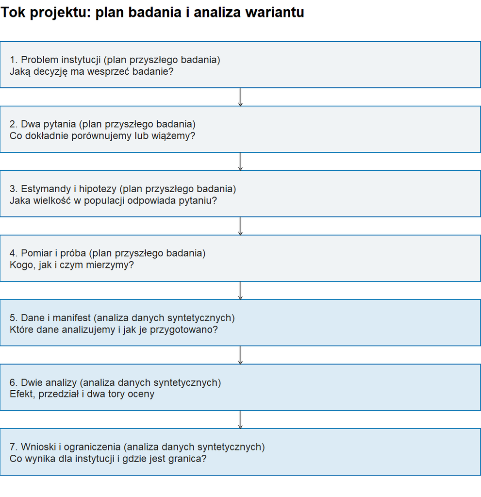

Tok projektu w siedmiu etapach, od góry do dołu. Etapy 1–4 (jaśniejsze tło) tworzą plan przyszłego badania: problem, dwa pytania, estymandy z hipotezami oraz pomiar i próbę. Etapy 5–7 (tło niebieskie) należą do analizy wariantu syntetycznego: dane z manifestem, dwie analizy oraz wnioski z ograniczeniami.

```r
tok <- pokaz_wykres(etapy_projektu())
print(tok)
```

Wykres „Tok projektu: plan badania i analiza wariantu” przedstawia siedem etapów: etapy 1–4 należą do planu przyszłego badania, a etapy 5–7 — do analizy wariantu syntetycznego. Zadanie Z09 obejmuje etapy 1–5 i pierwszy opis danych; zadanie Z10 na ćwiczeniu C10 obejmuje etapy 6–7.

## Projekt jako dziesięć zadań CHALLENGE

Projekt końcowy składa się z dziesięciu akapitów pisanych w zadaniach CHALLENGE i jednego pola uzupełnianego w raporcie. Pięć akapitów powstaje na ćwiczeniu C09 w zadaniu Z09 (plan i pierwszy opis danych), pięć — na ćwiczeniu C10 w zadaniu Z10 (dwie analizy, wnioski i rekomendacja). Po C10 funkcja `przygotuj_raport()` przenosi dziesięć akapitów do pliku `raport.Rmd`, w którym gotowe bloki R tworzą tabele i wykresy. Każdy blok R jest gotowy: praca nad projektem obejmuje wybór scenariusza, uruchamianie bloków i pisanie akapitów.

```r
mapa <- mapa_projektu()
print(mapa)
```

**Raport projektu: jedenaście pól i ich źródła**

Pole

Rozdział raportu

Akapit źródłowy

P01

1. Problem informacyjny i cel

Z09 S01

P02

2. Pytania, estymandy i plan analiz

Z09 S02

P03

3. Populacja, rekrutacja i operacjonalizacja

Z09 S03

P04

4. Dane i reguły przygotowania

Z09 S04

P05

4. Dane i reguły przygotowania

Z10 S01

P06

5. Opis próby i pomiarów

Z09 S05

P07

6. Pierwsza analiza

Z10 S02

P08

7. Druga analiza

Z10 S03

P09

8. Wnioski i ograniczenia

Z10 S04

P10

8. Rekomendacja

Z10 S05

P11

9. Źródła i odtworzenie

nowe pole raportu

Tabela „Raport projektu: jedenaście pól i ich źródła” przypisuje polom P01–P10 akapity S01–S05 zadań Z09 i Z10; pole P11 (bibliografia i zakres wsparcia narzędzi SI) powstaje w raporcie. Akapit z CHALLENGE 1 na C09 staje się więc rozdziałem 1 raportu, a akapit z CHALLENGE 5 — rozdziałem 5. Raport dopracowuje te same akapity w jeden tekst.

```r
ocena <- ocena_projektu()
print(ocena)
```

**Projekt końcowy: 100 punktów**

| Kryterium | Pola | Punkty |
| --- | --- | --- |
| A01 Problem, pytania, plan próby | P01–P03 | 15 |
| A02 Pomiar i indeks | P03 | 15 |
| A03 Przygotowanie danych | P04–P05 | 15 |
| A04 Opis próby i wykresy | P06 | 10 |
| A05 Dwie analizy | P02, P07–P08 | 20 |
| A06 Wnioski i rekomendacja | P09–P10 | 15 |
| A07 Odtwarzalność i źródła | P11 i pliki pracy | 10 |

Tabela „Projekt końcowy: 100 punktów” łączy siedem kryteriów oceny projektu z polami raportu: plan i pytania 15 punktów, pomiar 15, przygotowanie danych 15, opis próby 10, dwie analizy 20, wnioski i rekomendacja 15, odtwarzalność i źródła 10. Akapity Z09 dostarczają podstawy kryteriów A01–A04, a akapity Z10 — kryteriów A03, A05 i A06.

## Przebieg spotkania

Przeznacz około 5 minut na odtworzenie pracy, 30 minut na pięć bloków LEARN, 50 minut na pięć zadań CHALLENGE i 5 minut na zapis oraz oddanie. W LEARN czytasz plan i dane wspólnego przykładu S02. W CHALLENGE wybierasz scenariusz, uruchamiasz własny wariant i piszesz pięć akapitów pod wynikami, poza blokiem R. Gdy odczyt wyniku sprawia trudność, pytasz prowadzącego. Rozwinięcia po części obowiązkowej służą powtórce i pozostają poza oceną.

Bloki LEARN kończą się **wzorcem zapisu** — przykładowym zdaniem według standardu APA (*Publication Manual of the American Psychological Association*, 7. wydanie, 2020): symbol statystyczny kursywą, przedział w nawiasie kwadratowym, przecinek jako separator dziesiętny. Na ćwiczeniu C09 wzorce dotyczą części metodycznej raportu: pytań i hipotez, próby i pomiaru, przygotowania danych, opisu grup i źródeł.

# LEARN 1: Od problemu do dwóch estymand

Projekt rozdziela trzy poziomy opisu. Każdy poziom ma własny rodzaj twierdzenia i własne uzasadnienie.

**Problem instytucji.** Część odbiorców nie odnajduje dokumentu albo rezygnuje z usługi. Problem obejmuje osoby, zadanie, system i warunki dostępu, więc jego pełne rozpoznanie może wymagać kilku badań.

**Projekt badania.** Plan określa populację, rekrutację, standaryzowane zadanie, pomiar deklaracji i obserwację. Na poziomie projektu uzasadnia się operacjonalizację i ograniczenia: jakie dane instytucja musiałaby zebrać, aby rozważyć problem.

**Analiza dydaktyczna.** Generator dostarcza syntetyczne odpowiedzi do ćwiczenia statystyki. Analiza opisuje zbiór syntetyczny, szacuje efekty i niepewność procedur, a jej wyniki opisują dane syntetyczne scenariusza.

Trzy zdania ilustrują trzy poziomy: „biblioteka ma problem z filtrowaniem” jest twierdzeniem o instytucji, „badanie sprawdziłoby zrozumiałość nazw filtrów” — planem, a „w syntetycznej próbie średnia odpowiedź na pozycję 2 wyniosła 3,4” — opisem demonstracji. Plik ćwiczeniowy uzasadnia wyłącznie trzecie zdanie. Poprawny zapis metodyczny brzmi: „zaplanowano badanie użytkowników katalogu; tok analizy przeprowadzono na syntetycznych danych scenariusza S02”, a informacja o danych syntetycznych stoi na początku raportu.

Źródła z nauki o informacji uzasadniają sens pytania i pojęć: Wilson (1999) osadza pojedynczy wskaźnik w szerszym zachowaniu informacyjnym, Kuhlthau (1991) opisuje proces poszukiwania, Hargittai (2002) — pomiar umiejętności przez obserwację działań obok samoopisu, a Vial (2019) — zmianę organizacyjną związaną z technologią. Lokalny wynik o konkretnej instytucji wymaga lokalnego badania.

## Z problemu dwa pytania

Pytanie „Czy katalog jest dobry?” pozostawia otwarte cztery elementy: odbiorcę, zadanie, wskaźnik i kryterium. Plan „wykonam test t, korelację i chi-kwadrat” zaczyna od procedur. Dobre pytanie wskazuje odbiorcę, zadanie, wskaźnik i porównanie, a procedury dobiera się do pytań.

W scenariuszu S02 pierwsze pytanie dotyczy różnicy średniego indeksu deklarowanej użyteczności katalogu między nowymi i doświadczonymi użytkownikami, drugie — różnicy odsetka osób, które znalazły wskazany dokument. Pierwsze pytanie opiera się na deklaracji złożonej z sześciu pozycji, drugie na obserwacji wykonania zadania.

```r
karta <- karta_pytan_do_odczytu()
print(karta)
```

**Karta pytań S02**

| Element | Pytanie 1 | Pytanie 2 |
| --- | --- | --- |
| Pytanie | O ile ocena katalogu nowych różni się od oceny doświadczonych? | O ile odsetek znalezionych dokumentów u nowych różni się od odsetka u doświadczonych? |
| Pomiar | Indeks użyteczności katalogu (deklaracja, 1–5) | Znalezienie wskazanego dokumentu (obserwacja, 0/1) |
| Kolejność grup | nowi minus doświadczeni | nowi minus doświadczeni |
| Estymanda | różnica średnich indeksu w populacji | różnica odsetków kodu 1 w populacji |
| Jednostka efektu | punkty indeksu | punkty procentowe |
| Liczebność | ważny indeks i grupa | ważna wartość 0/1 i grupa |
| Tor klasyczny | test Welcha i CI różnicy | chi-kwadrat albo Fisher i CI różnicy odsetków |
| Tor losowany | tasowanie etykiet grup | tabele przy stałych marginesach |

Tabela „Karta pytań S02” zestawia dwa pytania w ośmiu wierszach: pytanie, pomiar, kolejność grup, estymandę, jednostkę efektu, liczebność i dwa tory oceny. Test Welcha i tasowanie etykiet to dwa tory pierwszego pytania; test chi-kwadrat i tabele Monte Carlo — dwa tory drugiego pytania. Projekt obejmuje więc dwie analizy, każdą z dwoma torami.

Kryterium podziału na grupy ustala protokół przed rekrutacją: miesiące korzystania, liczba sesji albo samookreślenie. Populację docelową nazywa się konkretnie, np. „osoby uprawnione do korzystania z katalogu w semestrze zimowym 2026/27”.

Pytanie pasuje do danych. Pytanie o poprawę po szkoleniu wymaga pomiaru przed szkoleniem i po nim, a pytanie o przebieg wyszukiwania — zapisu kolejnych kroków. Zbiór projektu zawiera dwie grupy obserwowane raz, łączny czas i wynik zadania, więc właściwe są pytania o różnicę grup i o związek dwóch pomiarów.

## Estymanda porządkuje plan

Estymanda to wielkość w populacji, o której badanie ma dostarczyć informacji. Dla pierwszego pytania:

$$\Delta_\mu=\mu_{\text{nowi}}-\mu_{\text{doświadczeni}}.$$

Symbol $\mu_{\text{nowi}}$ oznacza średni indeks wszystkich nowych użytkowników populacji, a różnica $\Delta_\mu$ ma jednostkę punktów indeksu. Kolejność „nowi minus doświadczeni” nadaje znakowi znaczenie: ujemna estymata oznacza niższą średnią nowych.

Dla drugiego pytania:

$$\Delta_\pi=\pi_{\text{nowi}}-\pi_{\text{doświadczeni}},$$

gdzie $\pi_g$ oznacza odsetek osób z kodem 1 (znaleziony dokument) w grupie $g$ populacji. Różnica proporcji leży między $-1$ a $1$; po pomnożeniu przez 100 jej jednostką są punkty procentowe. V Craméra opisuje natężenie związku, a kierunek i wielkość różnicy podaje $\Delta_\pi$.

W scenariuszu korelacyjnym estymandą jest korelacja rang $\rho_S$ indeksu z czasem albo z częstością korzystania w populacji. Częstość korzystania ma skalę porządkową: odstęp między „rzadko” i „czasami” może różnić się od odstępu między „często” i „bardzo często”, co uzasadnia korelację rang Spearmana.

Estymator to reguła obliczenia, np. różnica średnich w próbie; estymata — liczba otrzymana z tej reguły, np. $-0{,}438$ punktu; statystyka testowa odnosi estymatę do modelu zerowego, np. $t$ Welcha. Raport rozróżnia estymator, estymatę i statystykę testową.

Zakres estymandy wynika z definicji osób. „Średni czas użytkowników” i „średni czas osób, które znalazły dokument” to dwie estymandy: wykluczenie porażek zmienia pytanie i wymaga jawnej decyzji w planie. Indeks liczony przy co najmniej pięciu odpowiedziach dotyczy osób z pięcioma lub sześcioma ważnymi pozycjami; reguła jest jawna, a możliwa selekcja osób z pełniejszymi odpowiedziami pozostaje ograniczeniem.

## Hipoteza, przewidywanie i eksploracja

Hipoteza zerowa pierwszego pytania to $H_0\colon\Delta_\mu=0$. Hipoteza kierunkowa, np. niższa ocena nowych, wymaga argumentu z teorii albo wcześniejszego badania, sformułowanego przed analizą. Rodzaj testu ustala plan: test dwustronny odpowiada pytaniu o różnicę w obu kierunkach, a test jednostronny wymaga zapisanego wcześniej uzasadnienia kierunku i opisu konsekwencji wyniku przeciwnego.

Analiza eksploracyjna jest dozwolonym sposobem uczenia się o danych pod warunkiem nazwania jej eksploracyjną; wzorzec odkryty w eksploracji jest hipotezą dla nowego badania. Wyniki S02 są znane z wcześniejszych ćwiczeń, więc plan oddziela uzasadnienie merytoryczne od obserwacji dydaktycznych z ćwiczeń C06–C08, a decyzje dla własnego wariantu zapisuje się przed odczytem testów na C10.

Plan „porównam wszystkie zmienne i napiszę hipotezę dla tej, która ma p < 0,05” wybiera hipotezę po wyniku. Poprawny plan określa pytanie główne, wynik i metodę przed analizą, a dodatkowe przeglądy oznacza jako eksplorację z uwzględnieniem liczby wykonanych testów.

**Wzorzec zapisu pytań i hipotez (APA).**

> Pierwsze pytanie badawcze dotyczy różnicy średniego indeksu użyteczności katalogu (skala 1–5) między nowymi a doświadczonymi użytkownikami. Estymandą jest różnica średnich w populacji, $\Delta_\mu=\mu_{\text{nowi}}-\mu_{\text{doświadczeni}}$, wyrażona w punktach indeksu; hipotezę zerową $H_0\colon\Delta_\mu=0$ weryfikuje dwustronny test *t* Welcha z 95% przedziałem ufności oraz test permutacyjny. Drugie pytanie dotyczy różnicy odsetka osób, które znalazły wskazany dokument, $\Delta_\pi=\pi_{\text{nowi}}-\pi_{\text{doświadczeni}}$, w punktach procentowych, przy hipotezie zerowej niezależności grupy i wyniku zadania.

# LEARN 2: Populacja, rama doboru i pomiar

Populacja docelowa to zbiór osób, których dotyczy wniosek; rama doboru — wykaz lub kanał dotarcia do nich; próba zrealizowana — osoby, które rzeczywiście wzięły udział. Trzy zbiory zwykle się różnią, a plan opisuje każdy z nich.

Kanał rekrutacji wyznacza, kto trafia do próby. Zaproszenie na ekranie katalogu dociera do aktywnych użytkowników, a osoby, które zrezygnowały z katalogu, pozostają poza ramą. Zaproszenie przy stanowisku pomocy nadreprezentuje osoby z problemami, a newsletter — osoby zainteresowane ofertą. Próba losowa wymaga opisu ramy i mechanizmu losowania.

Jednostką analizy w projekcie jest osoba z jednym zadaniem. Pięć prób jednej osoby to pięć pomiarów jednej jednostki; projekt z powtarzanymi próbami wymaga agregacji albo analizy pomiarów zależnych.

Większa liczba odpowiedzi zmniejsza niepewność losową, a osoby pominięte przez rekrutację pozostają pominięte. Plan nazywa mechanizm pominięcia i jego możliwy wpływ na wynik. Rozwinięcie „Liczebność i selekcja” pokazuje mechanizm selekcji na liczbach: te same średnie grup dają średnią całości 3,3 w populacji i 3,8 wśród odpowiadających.

## Pomiar deklaracji i pomiar obserwacyjny

Opis zmiennej podaje konstrukt, definicję operacyjną, skalę, zakres, kod braku i sposób uzyskania. Zapis „kompetencje cyfrowe — skala 1–5” pozostawia otwarte, czy odpowiedzi dotyczą działania, wiedzy, czy poczucia sprawności; zapis „deklarowana łatwość znalezienia lokalizacji dokumentu w tym katalogu, 1–5” zamyka to pytanie.

W S02 sześć pozycji dotyczy użyteczności katalogu. Pozycja 3 („Odczytanie rekordu wymaga ode mnie zgadywania.”) ma odwrotny kierunek: wysoka odpowiedź oznacza niską użyteczność. Po odwróceniu $6-x$ wszystkie pozycje mają wspólny kierunek, a indeks jest średnią przy co najmniej pięciu ważnych odpowiedziach.

Indeks jest roboczym narzędziem dydaktycznym. Walidacja wymaga argumentu, że treść pozycji i sposób odpowiadania pasują do konstruktu i do planowanego użycia wyniku; wysoka zgodność pozycji opisuje rzetelność, a trafność wymaga odrębnego argumentu o znaczeniu wyniku.

Obserwowany wynik zadania wymaga kryterium. Opis „znalazł informację” obejmuje trzy możliwe kryteria: otwarcie strony, wskazanie właściwego dokumentu albo wskazanie lokalizacji i warunków dostępu. Różne kryteria dają różne odsetki, więc kryterium ustala się przed pomiarem.

```r
protokol <- protokol_do_odczytu()
print(protokol)
```

**Protokół obserwacji w planowanym badaniu S02**

| Element | Treść |
| --- | --- |
| Start pomiaru czasu | po odczytaniu instrukcji zadania |
| Koniec pomiaru czasu | zgłoszenie wyniku albo zakończenie próby |
| Kryterium kodu 1 | wskazany właściwy dokument i jego lokalizacja lub dostęp |
| Pomoc | zapis rodzaju i momentu pomocy obserwatora |
| Przerwanie próby | oddzielny kod przerwania; kod 0 oznacza zakończenie bez poprawnego wskazania |
| Limit czasu | ustalony przed badaniem; wynik przy limicie oznacza czas co najmniej równy limitowi |
| Warunki | urządzenie i przeglądarka odnotowane dla każdej osoby |
| Jednostka analizy | osoba z jednym zadaniem |

Karta „Protokół obserwacji w planowanym badaniu S02” zawiera propozycję protokołu przyszłego badania w ośmiu wierszach: start i koniec pomiaru czasu, kryterium kodu 1, pomoc, przerwanie próby, limit czasu, warunki i jednostkę analizy. Standaryzacja startu, końca i pomocy chroni przed różnicami, które powstają z procedury, a zostałyby przypisane użytkownikom.

Limit czasu oddziela czas ukończenia od informacji „zadanie trwało co najmniej do limitu”. Wartość 15 przy limicie 15 minut oznacza czas co najmniej 15 minut, czyli obserwację cenzurowaną (ćwiczenie C03); czasy 8 i 12 minut są czasami ukończenia.

## Kwestionariusz odpowiada planowi

Pozycja kwestionariusza wskazuje obiekt i okres odniesienia. Pozycja „Zwykle dobrze radzę sobie z informacją” dotyczy ogólnej pewności siebie, a pozycja „Potrafię znaleźć lokalizację dokumentu w tym katalogu” — jednej funkcji konkretnego systemu. Pytanie o dwie treści, np. „filtry i komunikaty są jasne”, łączy dwie oceny; osobne pozycje wskazują element do poprawy.

Pozycja odwrócona wymaga prostego języka, bo podwójne przeczenie zwiększa trudność zdania; jasność pozycji odwróconej sprawdza pilotaż. Pytanie wielokrotnego wyboru o kanały kontaktu ma własną logikę: cztery zera oznaczają ważną odpowiedź bez wskazań, a cztery braki — pominięcie pytania; odsetki wskazań liczone względem osób mogą sumować się powyżej 100%.

Projekt zachowuje wspólny schemat sześciu pozycji i dwóch grup. Opis pomiaru zachowuje treść kolumn ze słownika scenariusza, a własny pomysł na inne narzędzie opisuje się jako kierunek dalszego badania. Pilotaż, w którym przyszli uczestnicy komentują instrukcję i pozycje, opisuje się jako plan, np. sprawdzenie zrozumienia kategorii „nowy”, końca zadania i pozycji odwróconej.

**Wzorzec zapisu próby i pomiaru (APA).**

> Populację docelową stanowią osoby uprawnione do korzystania z katalogu biblioteki w semestrze zimowym 2026/27. Uczestnicy zostaną zaproszeni przez ekran katalogu i przez newsletter; kanał ekranowy pomija osoby, które zrezygnowały z katalogu, co ogranicza wniosek do aktywnych użytkowników. Deklarowaną użyteczność zmierzy sześć pozycji na skali od 1 (*zdecydowanie nie*) do 5 (*zdecydowanie tak*), np. „Nazwy filtrów są dla mnie zrozumiałe”, a wynik zadania (0/1) zarejestruje obserwator według kryterium wskazania właściwej publikacji i jej lokalizacji.

# LEARN 3: Dane, manifest i tożsamość wariantu

Manifest zapisuje pochodzenie wariantu: ID, scenariusz, rocznik, wersję generatora, klucz wariantu, hash danych, liczbę rekordów i wersję R. Manifest identyfikuje analizowane dane, a jakość pomiaru i reprezentatywność ocenia plan badania.

Trzy pojęcia techniczne służą identyfikacji. **Hash** danych (skrót kryptograficzny SHA-256) to ciąg 64 znaków obliczony z zawartości danych: zmiana jednej wartości zmienia cały ciąg, więc zgodny hash potwierdza te same dane niezależnie od nazwy pliku i folderu. **Klucz wariantu** to hash obliczony z danych wejściowych generatora — ID, scenariusza, rocznika, wersji generatora i liczby rekordów; ten sam klucz oznacza to samo losowanie. **Suma SHA-256 wysłanego pliku** pojawia się w potwierdzeniu oddania i w rejestrze `oddania.csv`; identyfikuje wersję PDF przyjętą przez folder prowadzącego.

ID jest pseudonimem kursowym; projekt obejmuje wyłącznie dane syntetyczne, a oddane pliki trafiają wyłącznie do folderu prowadzącego, niewidocznego dla innych osób. Wariant losuje się raz: scenariusz i ID pozostają te same od Z09 do raportu. Losowanie kolejnych wariantów do chwili uzyskania „ciekawego” wyniku byłoby selekcją danych według efektu.

```r
print(wariant_demo)
```

**Karta wybranego wariantu**

| Element | Treść |
| --- | --- |
| Scenariusz | S02 — Katalog biblioteczny: użyteczność wyszukiwania |
| Problem usługi | Biblioteka chce ustalić, czy katalog wymaga dodatkowego wsparcia przy pierwszych kontaktach. Porównuje ocenę katalogu i wykonanie jednego zadania, ponieważ pozytywna opinia o interfejsie nie musi ozna… |
| Projekt badania | Obserwacyjne badanie przekrojowe; grupy nie są randomizowane. |
| Konstrukt indeksu | Ocena użyteczności katalogu |
| Pierwsze porównanie | nowi minus doświadczeni |
| Druga relacja | grupa × powodzenie znalezienia dokumentu |
| Klucz wariantu (grupy po 8 znaków) | f3aa8363 f1ceefda b4e79609 e117acc0 9e85ff34 949f94eb 62fe0035 0249611d |
| Hash SHA-256 danych (grupy po 8 znaków) | 5f8f14d1 6bfc7fc1 e3eb3930 6fa1610d fea065a7 068c689c e093e4bb 6c7a0c20 |

**Manifest wariantu: pochodzenie danych**

| Pole | Wartość |
| --- | --- |
| ID | demo001 |
| Scenariusz | S02 |
| Rocznik | 2026-27 |
| Wersja generatora | 1.0.0 |
| Rekordy surowe | 150 |
| Wersja R | 4.6.1 |
| Dane syntetyczne | tak |

Karta „Karta wybranego wariantu” i tabela „Manifest wariantu: pochodzenie danych” opisują wspólny przykład kursu: ID demo001, scenariusz S02, rocznik 2026-27, wersja generatora 1.0.0 i 150 rekordów surowych. Hash danych zaczyna się od grupy 5f8f14d1, a klucz wariantu — od grupy f3aa8363. W akapicie wystarcza pierwsza grupa ośmiu znaków; pełny ciąg pozostaje w manifeście.

## Reguły danych zapisuje się przed wynikiem

Plan przygotowania danych rozróżnia cztery kategorie: wartość nieprawidłową, brak, duplikat i poprawną, choć nietypową obserwację. Każda kategoria ma własną regułę, a opis „usunięto błędne dane” łączy je w jedną i ukrywa decyzje.

Wartość 99 oznacza brak tam, gdzie tak stanowi słownik: w pozycjach ankiety. Czas 99 minut mieści się w zakresie 0–120 i jest prawidłowym pomiarem, więc zamiana każdej liczby 99 na brak uszkodziłaby dane. Regułę stosuje się bez znajomości p: decyzja zależna od tego, czy wynik „się poprawi”, zmienia analizę w szukanie korzystnego wyniku.

Identyczny duplikat rozpoznaje się po zgodności całego rekordu, a dwa różne rekordy z tym samym ID wymagają wyjaśnienia ze źródła. Zamiana kodu braku zmienia komórkę, a osoba zostaje w tabeli: osoba bez indeksu wchodzi do analizy wyniku zadania. Każda analiza ma własne N wymaganych wartości; wspólna próba dla wszystkich analiz wymaga uzasadnienia.

```r
przygotowanie_demo <- przygotowanie_wariantu(wariant_demo)
print(przygotowanie_demo)
```

**Reguły gotowego skryptu**

| Element | Treść |
| --- | --- |
| Identyczne duplikaty | z kilku identycznych rekordów zostaje jeden; liczba osób maleje |
| Kod 99 | w pozycjach ankiety oznacza brak odpowiedzi i zmienia komórkę na NA; osoba zostaje w danych |
| Czas poza 0–120 min | zmienia komórkę czasu na NA; osoba zostaje w analizach bez czasu |
| Długi czas w zakresie 0–120 min | zostaje jako ważna obserwacja |
| Pozycja 3 | sformułowana odwrotnie; odwrócenie 6 − x nadaje jej kierunek pozostałych pozycji |
| Indeks | średnia sześciu pozycji przy co najmniej 5 ważnych odpowiedziach; przy 4 lub mniej indeks jest brakiem |

**Dziennik przygotowania: wykonane zmiany**

| Reguła | Liczba |
| --- | --- |
| N przed czyszczeniem | 150 |
| Usunięte identyczne duplikaty | 2 |
| Kod 99 zamieniony na NA | 4 |
| Czas poza 0–120 minut zamieniony na NA | 2 |
| N po czyszczeniu | 148 |

```r
liczebnosci_demo <- bilans_wariantu(wariant_demo)
print(liczebnosci_demo)
```

**Bilans liczebności**

| Zakres | N |
| --- | --- |
| Rekordy surowe | 150 |
| Osoby po usunięciu duplikatów | 148 |
| Analiza 1: osoby z ważnym indeksem | 147 |
| Osoby z ważnym czasem | 142 |
| Analiza 2: osoby z wartością 0/1 | 148 |

**Dostępne pomiary w grupach**

| Grupa | Osoby | Ważny indeks | Ważny czas | Najdłuższy ważny czas [min] | Wartość 0/1 |
| --- | --- | --- | --- | --- | --- |
| doświadczeni | 74 | 74 | 70 | 30,2 | 74 |
| nowi | 74 | 73 | 72 | 33,8 | 74 |

Tabela „Dziennik przygotowania: wykonane zmiany” podaje działania skryptu dla demo001: 150 rekordów surowych, 2 usunięte identyczne duplikaty, 4 kody 99 zamienione na braki i 2 czasy spoza 0–120 minut zamienione na braki; zostaje 148 osób. Tabela „Bilans liczebności” podaje N każdej analizy: 147 osób z ważnym indeksem (analiza 1), 142 osoby z ważnym czasem i 148 osób z wartością 0/1 (analiza 2). Tabela „Dostępne pomiary w grupach” rozdziela liczebności: po 74 osoby doświadczone i nowe, z ważnym indeksem u 74 i 73 osób; najdłuższe ważne czasy, 30,2 i 33,8 minuty, zostają w danych.

Surowa tabela pozostaje bez zmian, a odtwarzalność oznacza ponowne przejście od surowej tabeli do wyników przy tych samych regułach. Poprawa analizy następuje w regułach skryptu; ręczna edycja pliku z wynikami przerywa drogę od danych do wyniku.

**Wzorzec zapisu przygotowania danych (APA).**

> Zbiór surowy zawierał 150 rekordów; po usunięciu 2 identycznych powtórzeń analizy objęły 148 osób. Cztery odpowiedzi z kodem 99 w pozycjach ankiety zamieniono na braki, a 2 czasy spoza zakresu 0–120 min oznaczono jako braki czasu. Po odwróceniu pozycji 3 (6 − *x*) indeks obliczono jako średnią co najmniej 5 z 6 ważnych pozycji, co dało *N* = 147 osób (74 doświadczone, 73 nowe); analiza wyniku zadania objęła 148 osób.

# LEARN 4: Pierwszy opis i plan dwóch analiz

Pierwsza analiza porównuje dwie niezależne grupy według indeksu. Tor klasyczny obejmuje test Welcha i 95% CI różnicy średnich: test Welcha dopuszcza różne wariancje i liczebności grup, a wymaga niezależności obserwacji. Tor losowany tasuje etykiety grup; prosta wersja tasowania wymaga wymienialności, czyli równości rozkładów w grupach przy $H_0$. Efekt naturalny to różnica w punktach indeksu, a Hedges $g$ — liczba bez jednostki, która uzupełnia efekt naturalny.

Plan zapisuje także odczyt przedziału. Przedział obejmujący zero opisuje zakres różnic zgodnych z danymi po obu stronach zera; przedział po jednej stronie zera opisuje kierunek i wielkość różnicy obserwacyjnej, której praktyczne znaczenie i przyczynę ocenia się osobno.

```r
opis_demo <- pierwszy_opis_wariantu(wariant_demo)
print(opis_demo)
```

**Źródło do uzasadnienia planu**

| Element | Treść |
| --- | --- |
| Lektura scenariusza | [Hargittai (2002)](https://webuse.org/p/a09/): uzasadnij rozdzielenie deklaracji i obserwacji działania. Sześć pozycji oraz wyniki w tym scenariuszu nie pochodzą z narzędzia ani próby autorki. |

**Opis indeksu w grupach [pkt 1–5]**

| Grupa | Osoby | n (ważny indeks) | Średnia | SD | Mediana |
| --- | --- | --- | --- | --- | --- |
| doświadczeni | 74 | 74 | 3,510 | 0,704 | 3,500 |
| nowi | 74 | 73 | 3,072 | 0,687 | 3,167 |

**Różnica średnich w kolejności kontrastu**

| Kontrast | Różnica średnich [pkt] |
| --- | --- |
| nowi minus doświadczeni | -0,438 |

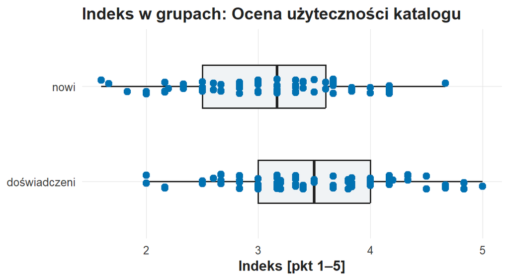

Indeks użyteczności katalogu w grupach S02 dla ID demo001. Oś pozioma: indeks w punktach 1–5; pudełko obejmuje środkowe 50% wyników, kreska w pudełku oznacza medianę, a punkty — pojedyncze osoby. Mediana doświadczonych wynosi 3,50, a nowych 3,17; rozkłady obu grup w dużej części się nakładają.

Tabela „Opis indeksu w grupach [pkt 1–5]” podaje dla S02: doświadczeni — 74 osoby, średnia 3,510, SD 0,704, mediana 3,500; nowi — 74 osoby, z czego 73 z ważnym indeksem, średnia 3,072, SD 0,687, mediana 3,167. Tabela „Różnica średnich w kolejności kontrastu” podaje $-0{,}438$ punktu dla kontrastu nowi minus doświadczeni. N ważnych indeksów wchodzi do SE i stopni swobody, więc analiza używa liczb 74 i 73, a liczba osób po czyszczeniu (74 i 74) opisuje próbę.

Wykres indeksu w grupach przedstawia rozkłady indeksu: pudełka obejmują środkowe 50% wyników, kreska oznacza medianę (3,50 u doświadczonych, 3,17 u nowych), a punkty — pojedyncze osoby. Rozkłady grup w dużej części się nakładają. Wykres opisuje położenie i rozrzut; niezależność obserwacji, sposób doboru i przyczynę różnicy ocenia plan badania. Karta „Źródło do uzasadnienia planu” wskazuje lekturę przypisaną scenariuszowi: dla S02 jest to Hargittai (2002), źródło rozdzielenia deklaracji i obserwacji działania.

```r
plan_demo <- plan_wariantu(wariant_demo)
print(plan_demo)
```

**Analiza 1 — porównanie grup**

| Element | Treść |
| --- | --- |
| Pomiar | Ocena użyteczności katalogu: średnia sześciu pozycji, skala 1–5 |
| Grupy i kolejność | nowi minus doświadczeni |
| Estymanda | różnica średnich indeksu w populacji: średnia (nowi) minus średnia (doświadczeni) |
| Jednostka efektu | punkty indeksu 1–5 |
| Hipoteza zerowa | H0: średnie w populacji są równe, różnica wynosi 0; test dwustronny |
| Tor klasyczny | test t Welcha z 95% CI różnicy średnich |
| Tor losowany | tasowanie etykiet grup (B = 1999) przy wymienialności; bootstrap osób w grupach daje drugi 95% CI |
| Liczebność | osoby ze znaną grupą i ważnym indeksem; osobne n każdej grupy |

**Analiza 2 — relacja ze scenariusza**

| Element | Treść |
| --- | --- |
| Pomiar | pole 0/1 — Czy udało się znaleźć wskazany dokument? Kod 1: wskazano właściwą publikację i jej lokalizację lub dostęp. |
| Grupy i kolejność | nowi minus doświadczeni |
| Estymanda | różnica odsetków kodu 1 w populacji: odsetek (nowi) minus odsetek (doświadczeni) |
| Jednostka efektu | punkty procentowe (pp) |
| Hipoteza zerowa | H0: grupa i pole 0/1 są niezależne, różnica odsetków wynosi 0 |
| Tor klasyczny | test chi-kwadrat (przy liczebności oczekiwanej poniżej 5: test Fishera) i 95% CI różnicy odsetków |
| Tor losowany | tabele Monte Carlo przy stałych marginesach (B = 1999); bootstrap osób w grupach daje drugi 95% CI |
| Miara uzupełniająca | V Craméra: natężenie związku bez kierunku |
| Liczebność | osoby ze znaną grupą i wartością 0/1; odsetki liczone w każdej grupie osobno |

Karty „Analiza 1 — porównanie grup” i „Analiza 2 — relacja ze scenariusza” zapisują plan obu analiz S02. Druga analiza S02 ma ścieżkę tabeli 2 × 2: odsetki kodu 1 liczy się w każdej grupie osobno, sprawdzenie liczebności oczekiwanych poprzedza wybór testu chi-kwadrat albo Fishera, a tabele Monte Carlo przy stałych marginesach tworzą tor losowany. Monte Carlo przybliża rozkład zerowy skończoną liczbą losowań (B = 1999). V Craméra jest nieujemne, a kierunek podaje przedział różnicy odsetków (ćwiczenie C07).

W scenariuszu korelacyjnym karta drugiej analizy podaje parę zmiennych, korelację rang Spearmana, test ze statystyką S, tasowanie jednej zmiennej i bootstrap całych par; przedział i p z tasowania dotyczą tej samej miary. Druga analiza obejmuje elementy potrzebne do pytania, a regresja z ćwiczenia C08 pozostaje rozszerzeniem.

## Nazwa techniczna a znaczenie pomiaru

Wspólna kolumna `powodzenie` ma w scenariuszach różne znaczenia: znalezienie dokumentu, poprawne wskazanie formularza albo napotkanie problemu. W S16 (informacja miejska) kod 1 oznacza zadeklarowane napotkanie sprzecznej informacji, więc wyższy odsetek jest wynikiem niekorzystnym. Znaczenie kodu 1 podaje karta scenariusza, a kierunek „korzystny” wynika z treści pytania. Wspólny `indeks` opisuje w różnych scenariuszach pewność, przejrzystość, zaufanie albo użyteczność dokumentacji; nazwa konstruktu pochodzi z karty scenariusza.

**Wzorzec zapisu opisu grup (APA).**

> Nowi użytkownicy (*n* = 73) uzyskali niższy średni indeks użyteczności katalogu (*M* = 3,07; *SD* = 0,69; *Mdn* = 3,17) niż doświadczeni (*n* = 74; *M* = 3,51; *SD* = 0,70; *Mdn* = 3,50); różnica nowi minus doświadczeni wynosi −0,44 punktu. Różnicę oceni test *t* Welcha z 95% CI oraz test permutacyjny (*B* = 1999), a różnicę odsetka znalezionych dokumentów — test chi-kwadrat z tabelami Monte Carlo i 95% CI różnicy odsetków.

# LEARN 5: Wybór scenariusza i literatura

Dwadzieścia scenariuszy ma ten sam schemat danych: dwie grupy, sześć pozycji ankietowych, czas zadania, pole 0/1, częstość korzystania i cztery kanały kontaktu. Pierwsza analiza każdego scenariusza porównuje indeks w grupach; druga analiza jest tabelą 2 × 2 (11 scenariuszy) albo korelacją rang Spearmana (9 scenariuszy).

```r
katalog <- katalog_projektow()
print(katalog)
```

**Dwadzieścia scenariuszy projektu**

| ID | Temat | Grupy porównania | Druga analiza |
| --- | --- | --- | --- |
| S01 | Wsparcie biblioteki w wyszukiwaniu | konsultacje / bez konsultacji | Spearman: indeks i częstość korzystania |
| S02 | Użyteczność katalogu | nowi / doświadczeni | tabela 2 × 2: grupa i pole 0/1 |
| S03 | Deklarowana znajomość otwartego dostępu | przeszkoleni / nieprzeszkoleni | Spearman: indeks i częstość korzystania |
| S04 | Informacja o wydarzeniach | WWW / media społecznościowe | tabela 2 × 2: grupa i pole 0/1 |
| S05 | Przejrzystość procedur w portalu | pierwszy rok / kolejny rok | Spearman: indeks i czas do zakończenia próby |
| S06 | Przydatność newslettera | regularni / okazjonalni | tabela 2 × 2: grupa i pole 0/1 |
| S07 | Zrozumiałość opisów archiwum | z doświadczeniem / bez doświadczenia | Spearman: indeks i częstość korzystania |
| S08 | Informacja w kolekcji muzealnej | edukacyjni / hobbystyczni | tabela 2 × 2: grupa i pole 0/1 |
| S09 | Nawigacja w BIP | często / rzadko | Spearman: indeks i czas do zakończenia próby |
| S10 | Dokumentacja danych badawczych | z doświadczeniem / bez doświadczenia | tabela 2 × 2: grupa i pole 0/1 |
| S11 | Instrukcje korzystania z e-zasobów | tekst / wideo | Spearman: indeks i czas zapoznania z instrukcją |
| S12 | Materiały na platformie nauczania | telefon / komputer | tabela 2 × 2: grupa i pole 0/1 |
| S13 | Adekwatność FAQ | pierwszy raz / powracający | tabela 2 × 2: grupa i pole 0/1 |
| S14 | Kontrola wyszukiwania przez filtry | filtry / bez filtrów | Spearman: indeks i częstość korzystania |
| S15 | Aktualność instrukcji w bazie wiedzy | krótki staż / długi staż | Spearman: indeks i czas do zakończenia próby |
| S16 | Spójność informacji miejskiej | jeden kanał / wiele kanałów | tabela 2 × 2: grupa i pole 0/1 |
| S17 | Czytelność opisów otwartych danych | zawodowi / niezawodowi | tabela 2 × 2: grupa i pole 0/1 |
| S18 | Jasność zasad dostępu | lokalni / zdalni | tabela 2 × 2: grupa i pole 0/1 |
| S19 | Trafność rekomendacji lektur | nowe zainteresowania / stałe zainteresowania | Spearman: indeks i częstość korzystania |
| S20 | Informacja o konferencji | pierwszy raz / kolejny raz | tabela 2 × 2: grupa i pole 0/1 |

Tabela „Dwadzieścia scenariuszy projektu” podaje ID, temat, grupy porównania i drugą analizę. Temat zmienia sens pomiaru i wniosku, a kod R pozostaje ten sam we wszystkich scenariuszach.

W CHALLENGE 1 zmieniasz jeden element kodu: kod scenariusza w cudzysłowie, np. `"S02"` na `"S14"`. Funkcja używa ID z początku sesji, a roboczy plik `zadanie.Rmd` zapisuje to samo ID w nagłówku (pole `id_studenta`), więc tworzenie PDF w nowej sesji korzysta z ID zapisanego w pliku. Własne ID widać w wydruku CHALLENGE 1 w wierszu „ID” tabeli „Manifest wariantu: pochodzenie danych”; publiczny podgląd materiału pokazuje w tym wierszu oznaczenie DEMO_C09.

Pierwsze uruchomienie bloku CHALLENGE 1 zapisuje wariant wraz ze słownikiem i kartą scenariusza w katalogu pracy, a kolejne uruchomienia odczytują ten zapis, także po aktualizacji pakietu. Kod scenariusza zmieniasz więc przed pierwszym uruchomieniem bloku; po pomyłce prowadzący pomaga odtworzyć zapis.

## Literatura potrzebna do uzasadnienia

Przegląd literatury zaczyna się od problemu, np. „samoopis a obserwowane umiejętności wyszukiwania”. Następnie identyfikuje pojęcie, sposób operacjonalizacji i projekt wcześniejszego badania, a na końcu ustala, co przenieść do własnego planu. Liczba cytowań wskazuje punkt wejścia do literatury; jakość konkretnego twierdzenia ocenia się w tekście publikacji.

Dla każdego źródła notatka zawiera cztery informacje: pełny opis bibliograficzny, DOI lub URL, pojęcie wykorzystane w projekcie i granicę przeniesienia. Hargittai (2002) uzasadnia pomiar wykonania obok samoopisu, a indeks deklarowanej użyteczności pozostaje innym narzędziem. Skala Internet Skills Scale (van Deursen, Helsper i Eynon, 2016) pomaga odróżnić wymiary umiejętności, a walidacja ISS dotyczy pozycji ISS. Wilson (1999) pomaga odróżnić pojedynczy wskaźnik zadania od szerszego zachowania informacyjnego.

Liczby z generatora opisują dane syntetyczne, a literatura dostarcza tła teoretycznego. Zdanie „zgodnie z Hargittai nowi użytkownicy uzyskali średnio 3,07” łączyłoby wynik syntetyczny z autorką, która go nie badała. Poprawny zapis oddziela tło (źródło), plan (projekt) i wynik (dane syntetyczne). Przy dostępnym wyłącznie abstrakcie notatka zaznacza zakres wykorzystania.

**Wzorzec zapisu źródła (APA).**

> Plan łączy samoopis z obserwacją wykonania zadania, co odpowiada postulatowi pomiaru umiejętności korzystania z sieci przez obserwację działań użytkowników (Hargittai, 2002).

> Hargittai, E. (2002). Beyond logs and surveys: In-depth measures of people’s web use skills. *Journal of the American Society for Information Science and Technology*, *53*(14), 1239–1244. https://doi.org/10.1002/asi.10166

# CHALLENGE — pierwsza karta własnego projektu

Pięć zadań tworzy plan własnego projektu na danych wybranego scenariusza. Akapity S01–S05 przechodzą później do raportu jako pola P01–P04 i P06 (tabela „Raport projektu: jedenaście pól i ich źródła”), więc wszystkie dotyczą jednego scenariusza i liczb własnego wariantu.

Każde z pięciu zadań ma ten sam układ:

1. **Zadanie** — jedno zdanie z przedmiotem opisu.
2. **Blok R** — uruchom go; wynik zawiera wszystkie informacje potrzebne do odpowiedzi.
3. **Wskazówki** — gdzie w wyniku szukać informacji, jak ją nazwać i wzór zdania do uzupełnienia.
4. **W akapicie wymagane** — elementy, które sprawdza prowadzący.
5. **Twój akapit** — pole odpowiedzi w ramce: znacznik w nawiasie kwadratowym zastępujesz własnym tekstem, a linie komentarza nad nim i pod nim pozostawiasz bez zmian.

Akapit liczy 3–6 zdań zwykłego tekstu, bez kodu R. Liczby przepisujesz z wyniku bloku, z jednostką i mianownikiem.

## CHALLENGE 1: Scenariusz, problem i pochodzenie danych

**Zadanie:** wybierz scenariusz, opisz problem usługi i decyzję, której służyłoby badanie, oraz pochodzenie własnego wariantu danych.

Przed pierwszym uruchomieniem bloku zmień w nim `"S02"` na kod wybranego scenariusza z tabeli „Dwadzieścia scenariuszy projektu”, np. `"S14"`, i zachowaj cudzysłów; to jedyna dozwolona zmiana kodu w zadaniu. Pierwsze uruchomienie zapisuje wariant na stałe, a zapis w pliku `zadanie.Rmd` (Ctrl+S) utrwala wybrany kod.

```r
projekt <- przygotuj_wariant_projektu(scenariusz = "S02")
print(projekt)
```

**Karta wybranego wariantu**

| Element | Treść |
| --- | --- |
| Scenariusz | S02 — Katalog biblioteczny: użyteczność wyszukiwania |
| Problem usługi | Biblioteka chce ustalić, czy katalog wymaga dodatkowego wsparcia przy pierwszych kontaktach. Porównuje ocenę katalogu i wykonanie jednego zadania, ponieważ pozytywna opinia o interfejsie nie musi ozna… |
| Projekt badania | Obserwacyjne badanie przekrojowe; grupy nie są randomizowane. |
| Konstrukt indeksu | Ocena użyteczności katalogu |
| Pierwsze porównanie | nowi minus doświadczeni |
| Druga relacja | grupa × powodzenie znalezienia dokumentu |
| Klucz wariantu (grupy po 8 znaków) | 999176fc 931c08a7 2d4c8ca6 3841b145 8ce3d9c2 ad700c7a aa0fa883 5676db7e |
| Hash SHA-256 danych (grupy po 8 znaków) | 34a356aa 295b519c dc7ed550 aca663be 4a20b960 8da81cc8 6a0b2019 4542358d |

**Manifest wariantu: pochodzenie danych**

| Pole | Wartość |
| --- | --- |
| ID | DEMO_C09 |
| Scenariusz | S02 |
| Rocznik | 2026-27 |
| Wersja generatora | 1.0.0 |
| Rekordy surowe | 150 |
| Wersja R | 4.6.1 |
| Dane syntetyczne | tak |

Blok wyświetla kartę „Karta wybranego wariantu” (scenariusz, problem usługi, projekt badania, konstrukt indeksu, pierwsze porównanie, druga relacja, klucz wariantu i hash danych) oraz tabelę „Manifest wariantu: pochodzenie danych”.

*Wskazówki:*

- Wiersz „Problem usługi” to punkt wyjścia: dopisz odbiorcę i decyzję, którą instytucja podjęłaby na podstawie badania, np. uruchomienie pomocy przy pierwszym wyszukiwaniu.
- Wiersz „ID” w manifeście podaje Twoje ID; oznaczenie DEMO_C09 występuje wyłącznie w publicznym podglądzie materiału.
- Z hasha danych podaj pierwszą grupę ośmiu znaków.
- Manifest identyfikuje dane: ID, scenariusz, rocznik, wersję generatora i liczbę rekordów. Jakość pomiaru i reprezentatywność należą do planu badania.
- Wzór zdania: „Projekt dotyczy scenariusza [kod] — [temat]: [instytucja] chce ustalić [problem], aby zdecydować, czy [decyzja]. Plan opisuje przyszłe badanie [kogo]; analiza obejmuje syntetyczny wariant danych (ID [..], rocznik [..], generator [..], [liczba] rekordów, hash zaczynający się od [8 znaków]), który identyfikuje manifest”.

*W akapicie wymagane:* (i) scenariusz i problem usługi własnymi słowami; (ii) odbiorca i decyzja, której służyłoby badanie; (iii) ID, rocznik, wersja generatora i liczba rekordów z manifestu oraz pierwsza grupa hasha; (iv) rozdzielenie planu rzeczywistego badania od analizy danych syntetycznych; (v) zakres informacji manifestu: identyfikacja danych.

**Twój akapit S01.** Znacznik w nawiasie kwadratowym zastąp własnym tekstem.

## CHALLENGE 2: Dwa pytania, estymandy i hipotezy

**Zadanie:** sformułuj dwa pytania badawcze z estymandami, kolejnością grup, jednostkami i hipotezami zerowymi.

```r
plan <- plan_wariantu(projekt)
print(plan)
```

**Analiza 1 — porównanie grup**

| Element | Treść |
| --- | --- |
| Pomiar | Ocena użyteczności katalogu: średnia sześciu pozycji, skala 1–5 |
| Grupy i kolejność | nowi minus doświadczeni |
| Estymanda | różnica średnich indeksu w populacji: średnia (nowi) minus średnia (doświadczeni) |
| Jednostka efektu | punkty indeksu 1–5 |
| Hipoteza zerowa | H0: średnie w populacji są równe, różnica wynosi 0; test dwustronny |
| Tor klasyczny | test t Welcha z 95% CI różnicy średnich |
| Tor losowany | tasowanie etykiet grup (B = 1999) przy wymienialności; bootstrap osób w grupach daje drugi 95% CI |
| Liczebność | osoby ze znaną grupą i ważnym indeksem; osobne n każdej grupy |

**Analiza 2 — relacja ze scenariusza**

| Element | Treść |
| --- | --- |
| Pomiar | pole 0/1 — Czy udało się znaleźć wskazany dokument? Kod 1: wskazano właściwą publikację i jej lokalizację lub dostęp. |
| Grupy i kolejność | nowi minus doświadczeni |
| Estymanda | różnica odsetków kodu 1 w populacji: odsetek (nowi) minus odsetek (doświadczeni) |
| Jednostka efektu | punkty procentowe (pp) |
| Hipoteza zerowa | H0: grupa i pole 0/1 są niezależne, różnica odsetków wynosi 0 |
| Tor klasyczny | test chi-kwadrat (przy liczebności oczekiwanej poniżej 5: test Fishera) i 95% CI różnicy odsetków |
| Tor losowany | tabele Monte Carlo przy stałych marginesach (B = 1999); bootstrap osób w grupach daje drugi 95% CI |
| Miara uzupełniająca | V Craméra: natężenie związku bez kierunku |
| Liczebność | osoby ze znaną grupą i wartością 0/1; odsetki liczone w każdej grupie osobno |

Blok wyświetla karty „Analiza 1 — porównanie grup” i „Analiza 2 — relacja ze scenariusza” z pomiarem, kolejnością grup, estymandą, jednostką efektu, hipotezą zerową, dwoma torami i liczebnością.

*Wskazówki:*

- Pytanie o różnicę zaczyna się od „O ile…”, a pytanie o korelację rang — od „Jak silny i w którą stronę…”; pytanie nazywa grupy, pomiar i jednostkę.
- Kolejność grup z wiersza „Grupy i kolejność” nadaje znakowi znaczenie: różnica ujemna oznacza niższą wartość pierwszej wymienionej grupy.
- Dwa tory, klasyczny i losowany, oceniają to samo pytanie; projekt ma dwie analizy, każdą z dwoma torami.
- Kierunek przewidywania wymaga argumentu sprzed analizy (źródło albo mechanizm); przy braku argumentu kierunkowego hipoteza jest dwustronna.
- Wzorzec APA: „Pierwsze pytanie brzmi: o ile średni indeks [konstrukt] w grupie [A] różni się od średniej w grupie [B]? Estymandą jest różnica średnich w populacji ([A] minus [B], punkty indeksu), a *H*<sub>0</sub> zakłada równość średnich. Drugie pytanie brzmi: [..]; estymandą jest [..] ([jednostka]), a *H*<sub>0</sub> zakłada niezależność [..]”.

*W akapicie wymagane:* (i) dwa pytania zgodne z kartami; (ii) estymanda i jednostka każdego pytania; (iii) kolejność grup w pierwszym pytaniu, a przy tabeli 2 × 2 także w drugim; (iv) obie hipotezy zerowe; (v) dwa tory jednej analizy odróżnione od dwóch pytań.

**Twój akapit S02.** Znacznik w nawiasie kwadratowym zastąp własnym tekstem.

## CHALLENGE 3: Populacja, rekrutacja i pomiar

**Zadanie:** zaplanuj populację, dobór i pomiar przyszłego badania z dostarczonym kwestionariuszem.

```r
pomiar <- pomiar_wariantu(projekt)
print(pomiar)
```

**Kwestionariusz i pomiary w wybranym scenariuszu**

| Element | Treść |
| --- | --- |
| Pozycja 1 | Szybko znajduję pole wyszukiwania w katalogu. |
| Pozycja 2 | Nazwy filtrów są dla mnie zrozumiałe. |
| Pozycja 3 | Odczytanie rekordu wymaga ode mnie zgadywania. |
| Pozycja 4 | Potrafię znaleźć lokalizację dokumentu. |
| Pozycja 5 | Komunikaty katalogu pomagają mi poprawić zapytanie. |
| Pozycja 6 | Katalog wspiera wykonanie mojego zadania. |
| Kontekst pozycji | Po zadaniu oceń zasób i własne doświadczenie korzystania. Pozycje dotyczące historii odnieś do ostatnich czterech tygodni. Jeśli treści nie da się ocenić, pozostaw brak zamiast zgadywać lub wybierać 3… |
| Odpowiedzi na pozycje | 1 zdecydowanie nie, 2 raczej nie, 3 ani tak, ani nie, 4 raczej tak, 5 zdecydowanie tak. |
| Kierunek i kompletność | Pozycja 3 po odwróceniu 6 − x; indeks jest średnią przy co najmniej 5 z 6 ważnych pozycji. |
| Definicja grup | Nowi: korzystający z tego katalogu po raz pierwszy; doświadczeni: korzystający wcześniej. Doświadczenie dotyczy konkretnego katalogu, nie ogólnej sprawności cyfrowej. Rekrutacja tylko przy stanowisku … |
| Zadanie obserwacyjne | Znajdź wskazaną publikację i wskaż lokalizację egzemplarza lub właściwy dostęp elektroniczny. |
| Czas | Czas do zakończenia próby |
| Protokół czasu | Od udostępnienia zadania do zgłoszenia odpowiedzi lub zakończenia próby, w minutach, niezależnie od jej wyniku. Czas nie jest automatycznie czasem dojścia do poprawnej odpowiedzi. |
| Częstość korzystania | Deklarowana częstość korzystania z opisanego zasobu w ostatnich czterech tygodniach przed zadaniem: 1 nigdy, 2 rzadko, 3 czasami, 4 często, 5 bardzo często. Są to kategorie porządkowe, nie liczba wizy… |
| Treść pola 0/1 | Czy udało się znaleźć wskazany dokument? |
| Źródło pola 0/1 | obserwacja |
| Kod 1 | wskazano właściwą publikację i jej lokalizację lub dostęp |
| Kod 0 | zakończono próbę bez poprawnego wskazania |
| Granica odczytu pola 0/1 | Wynik zależy od tego konkretnego zadania i katalogu; nie uzasadnia diagnozy wszystkich umiejętności użytkownika. |
| Kanały (odpowiedź wielokrotna) | strona WWW, e-mail, media społecznościowe, kontakt bezpośredni |

Blok wyświetla kartę „Kwestionariusz i pomiary w wybranym scenariuszu”: sześć pozycji, kontekst i skalę odpowiedzi, regułę indeksu, definicję grup, zadanie obserwacyjne, protokół czasu, częstość korzystania, treść i kody pola 0/1 oraz kanały.

*Wskazówki:*

- Populacja: kto, w jakiej instytucji i w jakim okresie; rama: kanał zaproszenia; selekcja: kogo kanał zaproszenia pomija.
- Kryterium grup podaje wiersz „Definicja grup”; plan ustala je przed rekrutacją.
- Wybierz jedną pozycję i nazwij aspekt konstruktu, który mierzy; pozycja 3 ma odwrotny kierunek.
- Drugi pomiar przy tabeli 2 × 2: kryterium kodu 1 i kodu 0 (wiersze „Kod 1”, „Kod 0” i „Źródło pola 0/1”); przy Spearmanie z czasem: start, koniec i jednostka z wiersza „Protokół czasu”; przy Spearmanie z częstością: okres odniesienia z wiersza „Częstość korzystania”.
- Ankieta daje deklarację, a zadanie — obserwację. Badanie i pilotaż opisujesz w czasie przyszłym, jako plan.
- Wzór zdania: „Populację stanowią [..] w [okres]; zaproszenie przez [kanał] dociera do [..], a pomija [..]. Grupę [A] tworzą [..]. Pozycja „[treść]” mierzy [aspekt]. Drugi pomiar to [definicja, kryterium lub protokół]. Pilotaż sprawdzi [..]”.

*W akapicie wymagane:* (i) populacja, okres i rama dotarcia; (ii) kryterium obu grup; (iii) jeden mechanizm selekcji i jego skutek dla wniosku; (iv) jedna konkretna pozycja z nazwą mierzonego aspektu; (v) definicja drugiego pomiaru i rozróżnienie deklaracji od obserwacji, w czasie przyszłym.

**Twój akapit S03.** Znacznik w nawiasie kwadratowym zastąp własnym tekstem.

## CHALLENGE 4: Reguły przygotowania i liczebności

**Zadanie:** opisz działania gotowego skryptu na Twoich danych i podaj N każdej analizy.

```r
przygotowanie <- przygotowanie_wariantu(projekt)
print(przygotowanie)
```

**Reguły gotowego skryptu**

| Element | Treść |
| --- | --- |
| Identyczne duplikaty | z kilku identycznych rekordów zostaje jeden; liczba osób maleje |
| Kod 99 | w pozycjach ankiety oznacza brak odpowiedzi i zmienia komórkę na NA; osoba zostaje w danych |
| Czas poza 0–120 min | zmienia komórkę czasu na NA; osoba zostaje w analizach bez czasu |
| Długi czas w zakresie 0–120 min | zostaje jako ważna obserwacja |
| Pozycja 3 | sformułowana odwrotnie; odwrócenie 6 − x nadaje jej kierunek pozostałych pozycji |
| Indeks | średnia sześciu pozycji przy co najmniej 5 ważnych odpowiedziach; przy 4 lub mniej indeks jest brakiem |

**Dziennik przygotowania: wykonane zmiany**

| Reguła | Liczba |
| --- | --- |
| N przed czyszczeniem | 150 |
| Usunięte identyczne duplikaty | 2 |
| Kod 99 zamieniony na NA | 4 |
| Czas poza 0–120 minut zamieniony na NA | 2 |
| N po czyszczeniu | 148 |

```r
liczebnosci <- bilans_wariantu(projekt)
print(liczebnosci)
```

**Bilans liczebności**

| Zakres | N |
| --- | --- |
| Rekordy surowe | 150 |
| Osoby po usunięciu duplikatów | 148 |
| Analiza 1: osoby z ważnym indeksem | 147 |
| Osoby z ważnym czasem | 142 |
| Analiza 2: osoby z wartością 0/1 | 148 |

**Dostępne pomiary w grupach**

| Grupa | Osoby | Ważny indeks | Ważny czas | Najdłuższy ważny czas [min] | Wartość 0/1 |
| --- | --- | --- | --- | --- | --- |
| doświadczeni | 74 | 74 | 69 | 43,9 | 74 |
| nowi | 74 | 73 | 73 | 23,6 | 74 |

Blok wyświetla kartę „Reguły gotowego skryptu” oraz tabele „Dziennik przygotowania: wykonane zmiany”, „Bilans liczebności” i „Dostępne pomiary w grupach”.

*Wskazówki:*

- Usunięcie duplikatu zmniejsza liczbę osób; zamiana kodu 99 albo czasu spoza zakresu zmienia jedną komórkę, a osoba zostaje w danych.
- N analizy 1 to liczba osób z ważnym indeksem, a N analizy 2 — liczba osób z wartością 0/1 albo kompletnych par; obie liczby podaje tabela „Bilans liczebności”.
- Odwrócenie 6 − x uzgadnia kierunek pozycji 3 z pozostałymi pozycjami; minimum 5 z 6 zachowuje osoby z jednym brakiem.
- Kolumna „Najdłuższy ważny czas [min]” podaje długie czasy z zakresu 0–120 min, które zostają jako ważne obserwacje.
- Wzorzec APA: „Zbiór surowy zawierał [..] rekordów; po usunięciu [..] identycznych powtórzeń analizy objęły [..] osób. [..] odpowiedzi z kodem 99 zamieniono na braki, a [..] czasów spoza zakresu 0–120 min oznaczono jako braki czasu. Indeks … obliczono dla *N* = [..] osób; analiza 2 objęła [..]”.

*W akapicie wymagane:* (i) N surowe i N po usunięciu duplikatów; (ii) liczba kodów 99 i czasów spoza zakresu; (iii) różnica między usunięciem rekordu a zmianą komórki; (iv) N obu analiz; (v) uzasadnienie reguł 6 − x i 5 z 6 oraz zachowania długich ważnych czasów.

**Twój akapit S04.** Znacznik w nawiasie kwadratowym zastąp własnym tekstem.

## CHALLENGE 5: Pierwszy opis i plan analiz

**Zadanie:** opisz indeks w grupach, odczytaj wykres i zapowiedz plan obu analiz z argumentem ze źródła.

```r
opis <- pierwszy_opis_wariantu(projekt)
print(opis)
```

**Źródło do uzasadnienia planu**

| Element | Treść |
| --- | --- |
| Lektura scenariusza | [Hargittai (2002)](https://webuse.org/p/a09/): uzasadnij rozdzielenie deklaracji i obserwacji działania. Sześć pozycji oraz wyniki w tym scenariuszu nie pochodzą z narzędzia ani próby autorki. |

**Opis indeksu w grupach [pkt 1–5]**

| Grupa | Osoby | n (ważny indeks) | Średnia | SD | Mediana |
| --- | --- | --- | --- | --- | --- |
| doświadczeni | 74 | 74 | 3,403 | 0,664 | 3,333 |
| nowi | 74 | 73 | 3,123 | 0,753 | 3,167 |

**Różnica średnich w kolejności kontrastu**

| Kontrast | Różnica średnich [pkt] |
| --- | --- |
| nowi minus doświadczeni | -0,28 |

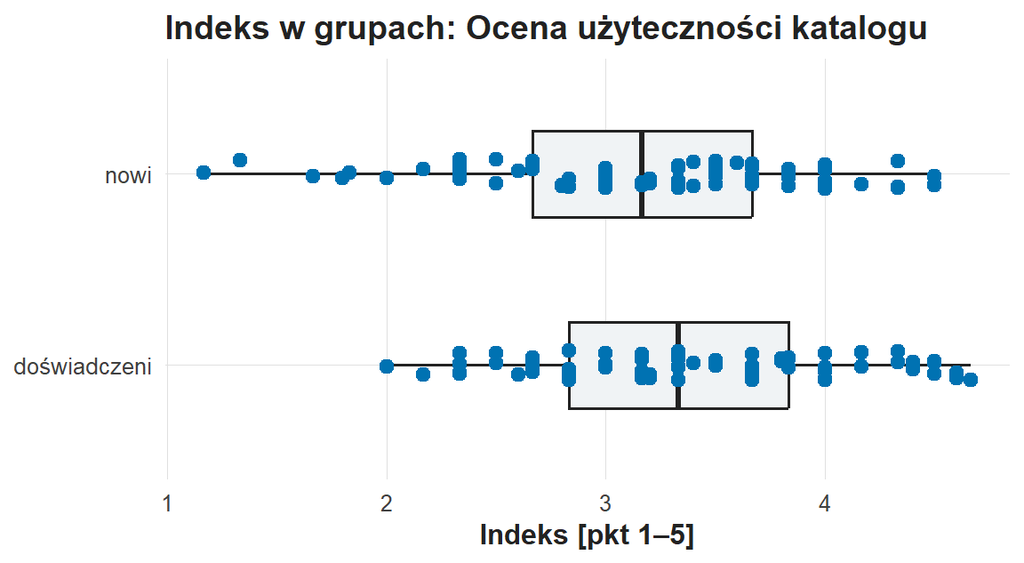

Indeks w grupach wybranego scenariusza. Oś pozioma: indeks w punktach 1–5; pudełko obejmuje środkowe 50% wyników, kreska w pudełku oznacza medianę, a punkty — pojedyncze osoby.

Blok wyświetla tabele „Opis indeksu w grupach [pkt 1–5]” i „Różnica średnich w kolejności kontrastu”, kartę „Źródło do uzasadnienia planu” oraz wykres indeksu w grupach.

*Wskazówki:*

- Średnia, SD i n pochodzą z pierwszej tabeli; n oznacza osoby z ważnym indeksem.
- Znak różnicy podaje druga tabela; kolejność grup jest ta sama co w CHALLENGE 2.
- Z wykresu odczytaj jedną konkretną cechę: medianę, rozrzut albo nakładanie się rozkładów.
- Niezależność obserwacji i sposób doboru osób leżą poza zasięgiem wykresu; ocenia je plan badania.
- Przedział obejmujący zero opisze na C10 zakres różnic zgodnych z danymi, z wartościami ujemnymi i dodatnimi.
- Karta „Źródło do uzasadnienia planu” podaje lekturę scenariusza; zapisz jeden argument ze źródła i jego granicę dla danych syntetycznych.
- Wzorzec APA: „Grupa [A] (*n* = [..]) uzyskała średni indeks *M* = [..] (*SD* = [..]), a grupa [B] (*n* = [..]) *M* = [..] (*SD* = [..]); różnica [A] minus [B] wynosi [..] punktu. Różnicę oceni test *t* Welcha z 95% CI i test permutacyjny (*B* = 1999), a [druga relacja] — [..]”.

*W akapicie wymagane:* (i) n, średnia i SD obu grup oraz różnica ze znakiem zgodnym z kontrastem; (ii) jedna cecha wykresu; (iii) oba tory oraz efekt z CI dla każdej z dwóch analiz; (iv) warunek oceniany poza wykresem i odczyt przedziału obejmującego zero; (v) jeden argument lub ograniczenie ze wskazanego źródła.

**Twój akapit S05.** Znacznik w nawiasie kwadratowym zastąp własnym tekstem.

# Zapis i oddanie

Sprawdź pięć własnych akapitów: wszystkie dotyczą wybranego scenariusza, liczby pochodzą z wydruków Twojego wariantu, a wiersz „ID” w manifeście podaje Twoje ID. Zapisz plik `zadanie.Rmd` w edytorze (Ctrl+S) razem z wybranym kodem scenariusza; funkcja oddania tworzy PDF z zapisanego pliku i zapisanego wariantu danych.

W konsoli wykonaj jedno polecenie. Funkcja oddania tworzy aktualny PDF, sprawdza tożsamość, kompletność i zgodność danych wariantu, otwiera PDF do obejrzenia i po potwierdzeniu literą `t` wysyła go do folderu zadania prowadzącego na serwerze UJ (nc.uj.edu.pl). Rmd, `analiza.R` i dane wariantu zostają w folderze `moje-badania` do C10 i raportu projektu.

```r
oddaj_zadanie("Z09")
```

Oddanie potwierdza komunikat z nazwą wysłanego pliku, folderem i czasem; plik `oddania.csv` w folderze `moje-badania` zapisuje także sumę SHA-256 wysłanego PDF. Po komunikacie błędu popraw wskazany problem, zapisz plik i ponownie wywołaj `oddaj_zadanie("Z09")`; ID i scenariusz pozostają bez zmian, a przy błędzie zapisu wariantu prowadzący pomaga odtworzyć pliki. Ocenę prowadzący przekazuje osobno.

Po potwierdzonym oddaniu możesz zamknąć projekt: Posit Cloud zachowuje folder `moje-badania` do kolejnych zajęć. Na komputerze współdzielonym wyloguj się z Posit Cloud w przeglądarce. Wybrany scenariusz, ID i zapisane akapity wracają na ćwiczeniu C10.

## Co jest oceniane

| Kryterium | Dowód w Twojej pracy | Odpowiedzi | Punkty |
| --- | --- | --- | --- |
| Z09.1 Własny scenariusz i pochodzenie wariantu | ID, scenariusz, rocznik i wersja generatora z manifestu; plan badania oddzielony od analizy danych syntetycznych | S01 | 2 |
| Z09.2 Problem, dwa pytania, estymandy i hipotezy | Problem i decyzja; dwa pytania z estymandami, hipotezami zerowymi, kolejnością grup i jednostkami; dwa tory jednej analizy | S01, S02 | 3 |
| Z09.3 Plan próby, treść pomiaru i reguły danych | Populacja, okres, rama, grupy i selekcja; konkretna pozycja i drugi pomiar; N, kody 99, czasy spoza zakresu, reguły 6 − x i 5 z 6, długie ważne czasy | S03, S04 | 3 |
| Z09.4 Pierwszy opis i plan dwóch analiz | Średnie, SD, n, znak różnicy i wykres; oba tory, efekt i CI obu analiz; warunek poza wykresem; argument ze źródła | S05 | 2 |

Ocena dotyczy sensu decyzji badawczych i poprawności odczytu. Poziomy wykonania opisuje rubryka Z09: na stronie kursu w dokumencie `rubryki/Z09.html`, a w konsoli R po poleceniu `rubryka("Z09")`.

# Rozwinięcia do powtórki — poza rdzeniem spotkania

Rozwinięcia pokazują selekcję, planowanie precyzji i próg praktycznej ważności oraz rozumowanie w trzech innych scenariuszach. Rozwinięcia służą powtórce i pozostają poza oceną.

## Liczebność i selekcja

W hipotetycznej populacji jest 700 nowych i 300 doświadczonych osób. Przykład przyjmuje średnie grupowe 3 i 4 oraz reprezentatywność odpowiadających wewnątrz swojej grupy. Do udziału zaproszono po 100 osób z każdej grupy, a odpowiedziało 20 nowych i 80 doświadczonych.

$$\mu=\sum_g w_g\,\mu_g,\qquad w_g=\frac{N_g}{N}.$$

Średnia populacji jest średnią grup ważoną udziałami grup w populacji: $\mu=0{,}7\cdot3+0{,}3\cdot4=3{,}3$. Nieważona średnia odpowiadających waży grupy udziałami w próbie: $\bar x=(20\cdot3+80\cdot4)/100=3{,}8$.

```r
selekcja_widok <- selekcja_do_odczytu()
print(selekcja_widok)
```

**Hipotetyczna rekrutacja**

| Grupa | Populacja | Zaproszeni | Odpowiedzi | Średnia grupy | Odpowiedzi [% zaproszonych] |
| --- | --- | --- | --- | --- | --- |
| Nowi | 700 | 100 | 20 | 3 | 20 |
| Doświadczeni | 300 | 100 | 80 | 4 | 80 |

**Średnia całości przy dwóch składach**

| Zbiór | Średnia |
| --- | --- |
| Cała hipotetyczna populacja | 3,3 |
| Odpowiadający | 3,8 |

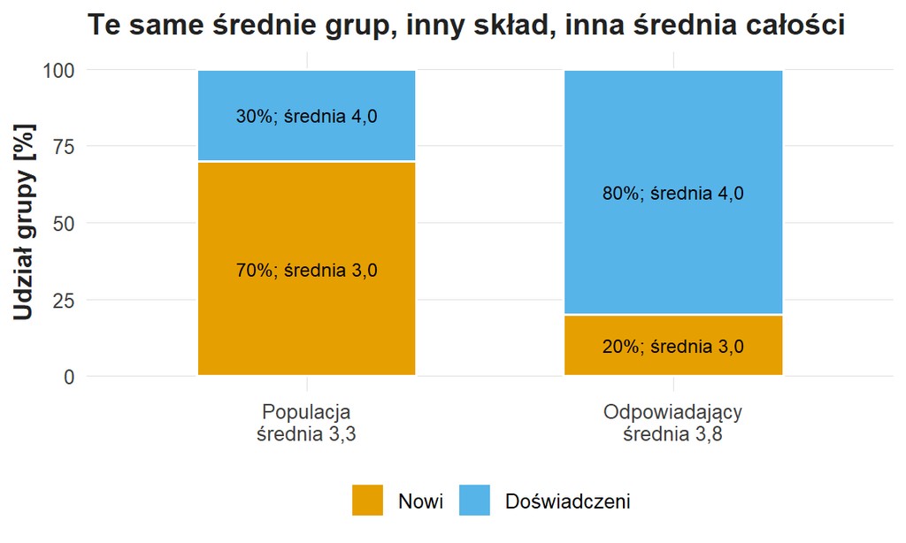

Skład grup w hipotetycznej populacji i wśród odpowiadających. Oś pionowa: udział grupy w procentach; segment słupka podaje udział i średnią grupy, a podpis słupka — średnią całości. Nowi stanowią 70% populacji i 20% odpowiadających; przy tych samych średnich grup (3 i 4) średnia całości rośnie z 3,3 do 3,8.

Tabela „Hipotetyczna rekrutacja” podaje odsetki odpowiedzi: 20% zaproszonych nowych i 80% zaproszonych doświadczonych. Tabela „Średnia całości przy dwóch składach” podaje 3,3 dla populacji i 3,8 dla odpowiadających, a wykres „Te same średnie grup, inny skład, inna średnia całości” przedstawia źródło różnicy: nowi stanowią 70% populacji i 20% odpowiadających. Powiększenie tak samo selektywnej próby daje bardziej precyzyjne oszacowanie liczby 3,8, czyli średniej innej populacji.

Ważenie do znanej struktury populacji (udziały 0,7 i 0,3) przywraca średnią 3,3 przy założeniu reprezentatywności odpowiadających wewnątrz grup. Różnice między odpowiadającymi i nieodpowiadającymi w tej samej grupie pozostają ograniczeniem. Opis selekcji w planie wskazuje, kogo pominięto i w którą stronę pominięcie może przesunąć wynik.

## Precyzja w planie

Liczebność dobiera się do potrzebnej precyzji, możliwego efektu, projektu i zasobów. W projekcie kursowym N generatora (150 rekordów) jest ustalone, a plan rzeczywistego badania uzasadnia własne N. Dla dwóch równych, niezależnych grup o roboczym odchyleniu standardowym $s$:

$$SE(\widehat\Delta)\approx s\sqrt{\frac{2}{n_g}},\qquad
E=1{,}96\,s\sqrt{\frac{2}{n_g}}
\quad\Longrightarrow\quad
n_g=2\left(\frac{1{,}96\,s}{E}\right)^2.$$

Symbol $n_g$ oznacza liczbę osób w jednej grupie, $s$ — roboczy SD indeksu, a $E$ — wymaganą połowę szerokości 95% CI. Przy $s=0{,}8$ i $E=0{,}2$ punktu: $n_g=2\,(1{,}96\cdot0{,}8/0{,}2)^2=2\cdot7{,}84^2\approx123$ osoby w każdej grupie.

```r
precyzja_widok <- precyzja_do_odczytu()
print(precyzja_widok)
```

**Przybliżenie przy SD = 0,8**

| n w grupie | SE różnicy [pkt] | Połowa szerokości CI [pkt] | N razem |
| --- | --- | --- | --- |
| 25 | 0,226 | 0,443 | 50 |
| 50 | 0,160 | 0,314 | 100 |
| 100 | 0,113 | 0,222 | 200 |
| 200 | 0,080 | 0,157 | 400 |

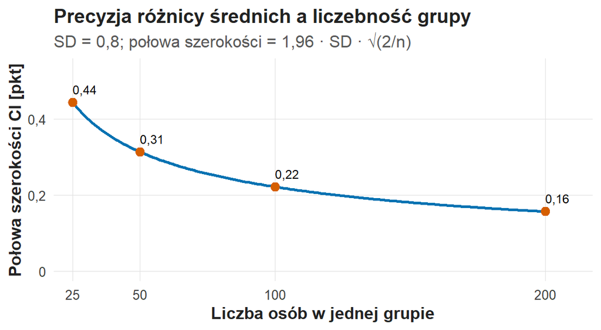

Połowa szerokości 95% CI różnicy średnich przy SD 0,8 wobec liczby osób w jednej grupie. Oś pozioma: n w grupie; oś pionowa: połowa szerokości w punktach indeksu. Krzywa opada od 0,44 przy 25 osobach przez 0,31 i 0,22 do 0,16 przy 200 osobach.

Tabela „Przybliżenie przy SD = 0,8” podaje połowę szerokości CI 0,443; 0,314; 0,222 i 0,157 punktu dla 25, 50, 100 i 200 osób w grupie. Wykres „Precyzja różnicy średnich a liczebność grupy” przedstawia krzywą opadającą od 0,44 do 0,16: podwojenie n zmniejsza połowę szerokości o czynnik $1/\sqrt2\approx0{,}71$ (z 0,31 do 0,22 punktu), a czterokrotne zwiększenie n — o połowę (z 0,44 do 0,22 punktu). Rachunek dotyczy niepewności losowej; błąd pomiaru i selekcja pozostają poza nim.

$$1-\beta\approx\Phi\!\left(\lvert d\rvert\sqrt{\frac{n_g}{2}}-1{,}96\right),\qquad d=\frac{\Delta}{s}.$$

Moc $1-\beta$ to prawdopodobieństwo odrzucenia $H_0$ dwustronnym testem na poziomie $\alpha=0{,}05$, gdy prawdziwy efekt standaryzowany wynosi $d$ (wykład W03); $\Phi$ oznacza dystrybuantę standardowego rozkładu normalnego. Dla $d=0{,}5$ i $n_g=64$: $1-\beta\approx\Phi(0{,}5\cdot\sqrt{32}-1{,}96)=\Phi(0{,}87)\approx0{,}81$; dla $d=0{,}3$ przy tym samym $n_g$: $\Phi(-0{,}26)\approx0{,}40$. Planowanie mocy wymaga efektu, wariancji, poziomu $\alpha$ i projektu, a moc opisuje procedurę przed zebraniem danych.

## Próg praktycznej ważności

Instytucja może uznać skrócenie przeciętnego czasu o dwie minuty za warte dalszego badania. Próg wynika z kosztu czasu, rodzaju zadania i konsekwencji błędu i ustala się go przed analizą. Przedział różnicy czasu [−1; 3] minuty obejmuje wartości po obu stronach progu 2 minut, więc dane pozostawiają otwarte, czy efekt przekracza próg; przedział [0,1; 0,3] minuty opisuje różnicę precyzyjną, niezerową i praktycznie małą. Minimalnie ważna różnica indeksu 1–5 wymaga wiedzy o narzędziu, a etykieta „średni efekt” dla Hedges $g$ opisuje wyłącznie wielkość standaryzowaną.

# Inne scenariusze: to samo rozumowanie przy innych danych

## Portal uczelni (S05): czas i przejrzystość

Instytucja chce ułatwić odnajdywanie procedur administracyjnych. Porównanie studentów pierwszego i kolejnych lat opisuje różnicę deklarowanej przejrzystości procedur, a korelacja rang indeksu z czasem — współzmienność oceny i wykonania. Efekt przeprojektowania strony wymaga porównania przed zmianą i po niej.

Plan ustala tę samą procedurę do odnalezienia dla wszystkich osób. Starsi studenci mogą szukać trudniejszych informacji, więc porównywalne zadania i zapis wcześniejszej znajomości procedury poprawiają przyszły projekt. Krótszy czas i niższa ocena przejrzystości mogą współwystępować: osoba zna ścieżkę na pamięć, a układ strony ocenia jako niejasny.

## Repozytorium uczelni (S03): szkolenie i deklarowana znajomość zasad

Grupy przeszkolonych i nieprzeszkolonych są obserwacyjne: osoby, które wybrały szkolenie, mogą mieć inną motywację i potrzeby, więc różnica indeksu opisuje związek szkolenia z deklaracją. Deklarowana znajomość zasad otwartego dostępu i rozwiązanie zadania licencyjnego to dwa pomiary; plan z zadaniem uzasadnia jego treść i kryterium poprawnej odpowiedzi. Rekomendacja proponuje badanie efektu szkolenia z losowym przydziałem albo z pomiarem przed szkoleniem i po nim, a wynik syntetyczny ilustruje analizę.

## Informacja miejska (S16): wiele kanałów i sprzeczne komunikaty

Osoby korzystające z wielu kanałów mają więcej okazji, by zauważyć sprzeczną informację. Większy odsetek zgłoszeń w grupie wielu kanałów ma więc dwa możliwe źródła: gorszą spójność komunikatów w kanałach albo liczbę okazji kontaktu. Kod 1 oznacza w S16 napotkanie problemu, więc wyższy odsetek jest wynikiem niekorzystnym. Pomiar liczby okazji kontaktu pozwala ocenić wyjaśnienie alternatywne.

## Krytyczna ocena propozycji narzędzia SI

Propozycja narzędzia SI zawiera celowe błędy:

> Przeprowadziliśmy losową ankietę 150 użytkowników. Wysoka rzetelność sześciu pytań potwierdza kompetencje cyfrowe. Test t pokaże, że szkolenie poprawia wyszukiwanie. Jeśli p będzie większe od 0,05, zastosujemy Spearmana. Dodatkowo sprawdzimy wszystkie kanały i wybierzemy najważniejszy wynik.

Propozycja zawiera siedem problemów. (1) Próba jest syntetyczna, a zdanie opisuje realną ankietę. (2) Losowość wymaga opisu ramy i mechanizmu doboru. (3) Treść sześciu pozycji dotyczy użyteczności katalogu, a propozycja mówi o kompetencjach. (4) Rzetelność opisuje spójność pozycji, a trafność — znaczenie wyniku. (5) Porównanie grup obserwacyjnych opisuje związek ze szkoleniem. (6) Test wybiera się przed analizą, a zmiana testu po odczycie p wynika z wyniku. (7) Dodatkowe analizy kanałów mają status eksploracyjny.

Poprawiona propozycja opisuje plan badania i osobno analizę syntetyczną, nazywa indeks, dwie estymandy, metody z warunkami i granicę wniosku przyczynowego. Narzędzie SI wskazuje niejasne zdania i objaśnia symbole; liczby, tytuły i wnioski sprawdza autor raportu, a zakres pomocy opisuje pole P11 raportu.

# Po spotkaniu

Karta Z09 zawiera wybrany temat, pochodzenie danych, dwa pytania, plan pomiaru i pierwsze liczby własnego wariantu. Plan pozostaje wykonalny przy każdym wyniku: raport opisze estymaty, przedziały, precyzję i ograniczenia niezależnie od wartości p.

Ćwiczenie C10 (Od wyniku do raportu) korzysta z tego samego wariantu: uruchamia obie analizy, a pięć akapitów Z10 dołącza do pięciu akapitów Z09 w raporcie projektu. Źródła tła i pomiaru wraz z pełnymi opisami zawiera bibliografia kursu.